# aCAP Exam Study Guide

## 10.23 **Question 23**

Once you’ve built your model how do you know that the model will still answer your business problem?

### 10.23.1 Answer

The answer is to go back to the original question or problem and see if that has been answered. There may be times when the original question or problem may have become only a part of the solution, but it still needs to have been answered.

### 10.23.2 Explanation

- **Revisiting the Original Problem**: Ensuring that the model still answers the business problem involves revisiting the original question or problem statement. This helps confirm that the model’s output and conclusions are relevant and directly address the initial business need.
- **Validation**: Regularly validating the model against the original problem ensures that the model remains aligned with the business objectives. This can involve checking if the model’s predictions and insights are consistent with the real-world outcomes and expectations.
- **Scope Adjustment**: Sometimes, the scope of the problem may evolve, and the model needs to adapt to these changes. Even if the problem has become a part of a larger solution, it is crucial that the original problem is still adequately addressed by the model.

In summary, revisiting the original problem and validating the model’s output against it ensures that the model continues to provide relevant and accurate answers to the business problem.

## 10.24 **Question 24**

In the business problem framing chapter, there’s an example of a manufacturing plant that has poor on-time performance. Imagine that you’ve built a simulation model of the plant that shows that it should be able to achieve much better results without requiring any new investment. What concerns might your stakeholders have?

### 10.24.1 Answer

Among other things, stakeholders may be concerned with the implications of the solution, the future impact on their business, whether the new solution will lead to more on-time performance in the long run, the ease of implementation, impact on personnel of changes in processes, and other concerns related to their way of doing business.

### 10.24.2 Explanation

- **Implications of the Solution**: Stakeholders might be concerned about how the proposed solution will affect current operations and whether it aligns with the overall strategic goals of the organization.
- **Long-term Impact**: Ensuring sustained improvement in on-time performance without new investments may raise questions about the long-term viability and scalability of the solution.
- **Ease of Implementation**: The practicality of implementing the new processes or changes suggested by the model is a common concern. Stakeholders need assurance that the implementation will be smooth and not disrupt existing workflows.
- **Impact on Personnel**: Changes in processes can impact staff, including their roles, responsibilities, and workload. Stakeholders may worry about how these changes will be managed and whether staff will require additional training or support.
- **Business Continuity**: Stakeholders will be interested in how the changes might affect business continuity and whether there are any risks of disruptions during the transition period.

In summary, stakeholder concerns often revolve around the practical implications, long-term impact, ease of implementation, and effects on personnel when considering a new solution proposed by a simulation model.

## 10.25 **Question 25**

When should you retire a model?

1. When its replacement has been validated
2. When a change in business conditions invalidate its assumptions
3. Both a and b
4. Neither a nor b

### 10.25.1 Answer

`c. Both a and b`. If a change in business conditions has occurred that invalidate the assumptions of the original model, a new or revised model should be fielded and tested and validated before being deployed as a replacement.

### 10.25.2 Explanation

- **Model Replacement**: Retiring a model is appropriate when its replacement has been validated. This ensures that the new model is reliable, accurate, and better suited to current business needs before the old model is phased out.
- **Invalidated Assumptions**: When changes in business conditions invalidate the assumptions of the original model, it is necessary to retire the old model. The outdated model may no longer provide accurate or relevant insights, necessitating the development and validation of a new model.

In summary, a model should be retired when either its replacement has been validated or when significant changes in business conditions render its assumptions invalid. Both scenarios ensure that the business continues to use accurate and relevant models for decision-making.

## 10.26 **Question 26**

How often should model maintenance be done?

1. When underlying assumptions change
2. When it is ported to a new system
3. When the data it uses changes its format
4. When it is transferred to a new owner

### 10.26.1 Answer

`a`. While maintenance is continual over the life of a model, maintenance is required when the underlying assumptions change.

### 10.26.2 Explanation

- **Underlying Assumptions**: The most critical factor necessitating model maintenance is a change in the underlying assumptions. If the assumptions that the model is based on no longer hold true, the model’s accuracy and relevance can be compromised. Therefore, it is essential to update the model to reflect new realities and assumptions.
- **Continual Maintenance**: Although regular maintenance is important, significant updates are particularly required when there are fundamental changes in the assumptions, data sources, or business environment that impact the model’s performance.

In summary, while model maintenance should be an ongoing process, it becomes especially crucial when the underlying assumptions change, ensuring that the model remains accurate and relevant to current conditions.

## 10.27 **Question 27**

What will happen if you don’t ever bother to evaluate model performance and returns over time?

### 10.27.1 Answer

If the model performance is not evaluated, over time the returns may become skewed and may not provide accurate answers to the original question.

### 10.27.2 Explanation

- **Model Degradation**: Without regular evaluation, the model’s performance may degrade over time due to changes in the underlying data, shifts in business conditions, or evolving market trends. This can lead to inaccurate predictions and poor decision-making.
- **Misalignment with Business Goals**: As business objectives and conditions change, the model may no longer align with the current goals and needs. Regular evaluation ensures that the model continues to be relevant and effective in addressing the original business problem.
- **Error Accumulation**: Over time, small errors and inaccuracies can accumulate, leading to significant deviations from expected outcomes. Regular performance checks help in identifying and correcting these errors early.
- **Loss of Trust**: If the model’s performance is not monitored and maintained, stakeholders may lose trust in the model’s outputs, undermining its utility and the credibility of the analytics team.
- **Financial Impact**: Poor model performance can have direct financial implications, such as increased costs, missed opportunities, or reduced revenue. Regular evaluation helps in mitigating these risks and ensuring positive returns on investment.

In summary, evaluating model performance and returns over time is crucial to maintaining accuracy, relevance, and trust in the model, ensuring it continues to provide valuable insights and support effective decision-making.

## 10.28 **Question 28**

Which of the following BEST describes the data and information flow within an organization?

1. Information assurance
2. Information strategy
3. Information mapping
4. Information architecture

### 10.28.1 Answer

`d. Information architecture`

Refers to the analysis and design of the data stored by information systems, concentrating on entities, their attributes, and their interrelationships. It refers to the modeling of data for an individual database and to the corporate data models that an enterprise uses to coordinate the definition of data in several (perhaps scores or hundreds) distinct databases.

### 10.28.2 Explanation

- **Information Architecture**: Information architecture focuses on the structured design and organization of information within an organization. It involves analyzing and designing how data is stored, accessed, and used, ensuring that data flows efficiently and effectively throughout the organization.
- **Entities and Relationships**: It deals with defining entities, their attributes, and the relationships between them, providing a clear model of how data is interconnected and managed.
- **Data Modeling**: Information architecture includes creating data models for individual databases as well as comprehensive corporate data models that integrate multiple databases. This ensures consistency, accuracy, and accessibility of data across the organization.

In summary, information architecture best describes the data and information flow within an organization by focusing on the structured design, storage, and interrelationships of data, ensuring efficient and effective information management.

## 10.29 **Question 29**

A multiple linear regression was built to try to predict customer expenditures based on 200 independent variables (behavioral and demographic). 10,000 randomly selected rows of data were fed into a stepwise regression, each row representing one customer. 1,000 customers were male, and 9,000 customers were female. The final model had an adjusted R-squared of 0.27 and seven independent variables. Increasing the number of randomly selected rows of data to 100,000 and rerunning the stepwise regression will MOST likely:

1. have negligible impact upon the adjusted R-squared.
2. increase the impact of the male customers.
3. change the heteroskedasticity of the residuals in a favorable manner.
4. decrease the number of independent variables in the final model.

### 10.29.1 Answer

`a. have negligible impact upon the adjusted R-squared.`

The increase in size of the data will not impact the adjusted R-squared calculation because both samples are sufficiently large randomly selected subsets of data.

### 10.29.2 Explanation

- **Sample Size and Adjusted R-squared**: Adjusted R-squared is a measure of the proportion of variability in the dependent variable explained by the independent variables, adjusted for the number of predictors in the model. With 10,000 rows of data already providing a substantial sample size, increasing the sample to 100,000 rows is unlikely to significantly change the adjusted R-squared value.
- **Sufficient Data**: The original sample of 10,000 rows is already large enough to provide a reliable estimate of the model’s explanatory power. Adding more data points typically has diminishing returns on the adjusted R-squared, especially when the initial sample is already robust.
- **Statistical Significance**: While increasing the sample size can improve the precision of the estimates and potentially identify more subtle relationships, the overall explanatory power of the model, as indicated by adjusted R-squared, is likely to remain stable.

In summary, increasing the number of randomly selected rows of data to 100,000 will most likely have negligible impact upon the adjusted R-squared because the initial sample size is already large enough to provide a reliable estimate of the model’s explanatory power.

## 10.30 **Question 30**

A clothing company wants to use analytics to decide which customers to send a promotional catalogue in order to attain a targeted response rate. Which of the following techniques would be the MOST appropriate to use for making this decision?

1. Integer programming
2. Logistic regression
3. Analysis of variance
4. Linear regression

### 10.30.1 Answer

`b. Logistic regression`

This type of classification model is often used to predict the outcome of a categorical dependent variable (response vs. no response) based on one or more predictor variables, so this is the most appropriate answer. The goal of the analytics in the stated problem is to determine who is most likely to respond, and the binary nature of this predicted outcome is provided by logistic regression.

### 10.30.2 Explanation

- **Binary Classification**: Logistic regression is specifically designed for binary classification problems where the outcome variable is categorical (e.g., response vs. no response). It models the probability of a certain class or event existing.
- **Predicting Likelihood of Response**: In this scenario, the clothing company needs to predict which customers are likely to respond to the promotional catalogue. Logistic regression is well-suited for this task as it estimates the probability of response based on various predictor variables such as purchase history, demographics, and behavioral data.
- **Decision Making**: By identifying customers with the highest probability of responding, the company can target its promotional efforts more effectively, improving response rates and maximizing return on investment.

In summary, logistic regression is the most appropriate technique for deciding which customers to send a promotional catalogue to achieve a targeted response rate, as it effectively handles binary classification problems and predicts the likelihood of customer response based on multiple predictors.

## 10.31 **Question 31**

Which of the following is an effective optimization method?

1. Analysis of variance (ANOVA)
2. Generalized linear model (GLM)
3. Box-Jenkins Method (ARIMA)
4. Mixed integer programming (MIP)

### 10.31.1 Answer

`d. Mixed integer programming (MIP)`

This is a mathematical optimization technique used when one or more of the variables are restricted to be integers. It is an effective optimization model.

### 10.31.2 Explanation

- **Mixed Integer Programming (MIP)**: MIP is an optimization method that extends linear programming to include integer variables. It is highly effective for solving complex decision-making problems that involve both continuous and discrete variables.
- **Versatility**: MIP can handle a wide range of problems in various fields such as logistics, finance, manufacturing, and scheduling.
- **Optimal Solutions**: By allowing some variables to be integers, MIP can model scenarios where decisions are binary (yes/no) or involve whole units, providing optimal solutions to problems that cannot be addressed by linear programming alone.

In summary, mixed integer programming is a robust and versatile optimization method used for complex problems involving integer constraints, making it the most effective choice among the options provided.

## 10.32 **Question 32**

A box and whisker plot for a dataset will MOST clearly show:

1. the difference between the 50th percentile and the median.
2. the 90% confidence interval around the mean.
3. where the [actual-predicted] error value is not zero.
4. if the data is skewed and, if so, in which direction.

### 10.32.1 Answer

`d. if the data is skewed and, if so, in which direction.`

### 10.32.2 Explanation

- **Box and Whisker Plot**: This plot visually displays the distribution of a dataset by showing the minimum, first quartile (Q1), median, third quartile (Q3), and maximum values.
- **Skewness**: The position of the median within the box and the length of the whiskers can indicate skewness. If the median is closer to the lower quartile (Q1) and the upper whisker is longer, the data is positively skewed. Conversely, if the median is closer to the upper quartile (Q3) and the lower whisker is longer, the data is negatively skewed.
- **Outliers**: Box plots also highlight outliers, which are data points that fall outside the whiskers.

In summary, a box and whisker plot effectively shows if the data is skewed and in which direction by displaying the distribution and identifying outliers.

## 10.33 **Question 33**

In the initial project meeting with a client for a new project, which of the following is the MOST important information to obtain?

1. Timeline and implementation plan
2. Analytical model to use
3. Business issue and project goal
4. Available budget

### 10.33.1 Answer

`c. Business issue and project goal.`

Understanding the business issue and project goal provides a sound foundation on which to base the project.

### 10.33.2 Explanation

- **Business Issue and Project Goal**: Clearly defining the business issue and project goal is crucial for aligning the project with the client’s needs and ensuring that the solution addresses the right problem.
- **Guiding the Project**: Understanding the business issue and goal helps in selecting the appropriate methodology, defining the project scope, and setting realistic expectations.
- **Stakeholder Alignment**: It ensures that all stakeholders have a shared understanding of the project’s purpose and objectives, facilitating better communication and collaboration throughout the project.

In summary, identifying the business issue and project goal is the most important information to obtain in the initial project meeting to ensure that the project is properly focused and aligned with the client’s needs.

## 10.34 **Question 34**

Which of the following statements is true of modeling a multi-server checkout line?

1. A queuing model can be used to estimate service rates.
2. A queuing model can be used to estimate average arrivals.
3. Variability in arrival and service times will tend to play a critical role in congestion.
4. Poisson distributions are not relevant.

### 10.34.1 Answer

`c. Variability in arrival and service times will tend to play a critical role in congestion.`

Arrival and service time distributions are inputs to a queuing model that would be used to model a checkout line and directly influence congestion.

### 10.34.2 Explanation

- **Variability Impact**: In a multi-server checkout line, variability in arrival and service times is a key factor influencing congestion. High variability can lead to longer wait times and queue lengths, while low variability can result in smoother operations.
- **Queuing Models**: These models are used to analyze and predict the behavior of waiting lines, incorporating factors such as arrival rates, service rates, and the number of servers.
- **Poisson Distributions**: Often relevant in queuing theory, Poisson distributions typically describe arrival rates in many real-world scenarios. However, they are not the primary focus of this question.

In summary, variability in arrival and service times plays a critical role in determining congestion levels in a multi-server checkout line, making it a true statement about queuing models.

## 10.35 **Question 35**

A company is considering designing a new automobile. Their options are a design based on current gasoline engine technology or a government proposed «Green» technology. You are a government official whose job is to encourage automakers to adopt the «Green» technology. You cannot provide funding for development costs, but you can provide a subsidy for every car sold. The development costs and the wholesale price, in thousands of dollars, of the cars are shown in the table below:

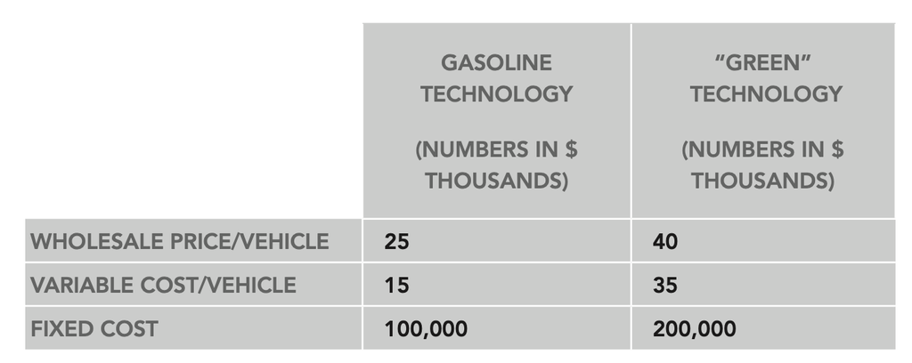

How large a subsidy per vehicle sold will be required, assuming there will be enough demand to motivate the switch?

1. Greater than $5000
2. Less than $5000
3. Cannot be determined
4. Equal to $5000

### 10.35.1 Answer

`a. Greater than $5000`

If we consider the profit from an individual vehicle to be the wholesale price minus the variable cost, we see that the profit from a Gasoline Technology vehicle is $25K - $15K = $10K. Similarly, the profit from a “Green” Technology vehicle is $40K - $35K = $5K.

In order to make up for this difference in lost profit, the subsidy provided to the automaker would have to be at least $5K (the difference between $10K and $5K). In addition, the subsidy would need to be greater than $5000 so that the automakers would be able to recover their increased fixed costs at a reasonable level of demand.

### 10.35.2 Explanation

- **Profit Comparison**: The profit per vehicle for gasoline technology is $10K, while for green technology, it is $5K. To make the green technology equally attractive, a subsidy of at least $5K per vehicle is needed to cover the profit shortfall.
- **Fixed Costs**: Considering the higher fixed development costs for green technology, the subsidy must exceed $5K to ensure automakers can recover these costs over time.

In summary, a subsidy greater than $5000 per vehicle is required to compensate for the lower profit margin and higher fixed costs associated with the green technology, making it a viable option for automakers.

## 10.36 **Question 36**

A furniture maker would like to determine the most profitable mix of items to produce. There are well-known budgetary constraints. Each piece of furniture is made of a predetermined amount of material with known costs, and demand is known. Which of the following analytical techniques is the MOST appropriate one to solve this problem?

1. Optimization
2. Multiple regression
3. Data mining
4. Forecasting

### 10.36.1 Answer

`a. Optimization`

The problem statement describes an optimization problem: the furniture maker’s objective function is to maximize his profit. The decision variables are the amount of each item to produce, and the constraints are that he must meet demand and be within his budget. Optimization is the most appropriate technique to solve this problem.

### 10.36.2 Explanation

- **Objective Function**: The goal is to maximize profit, which involves finding the best combination of items to produce.
- **Decision Variables**: These are the quantities of each item to be produced.
- **Constraints**: The constraints include the budgetary limits and the known demand for each item.
- **Optimization Technique**: Optimization is used to solve problems involving maximization or minimization of an objective function subject to constraints. In this case, linear programming or mixed-integer programming could be used to determine the most profitable mix of items.

In summary, optimization is the most appropriate technique to determine the most profitable mix of items to produce under given constraints.

## 10.37 **Question 37**

You have simulated the Net Present Value (NPV) of a decision. It ranges between $–10,000,000 and $+10,000,000. To best present the likelihood of possible outcomes, you should:

1. Present a single NPV estimate to avoid confusion.
2. Present a histogram to show the likelihood of various NPVs.
3. Trim all outliers to present the most balanced diagram.
4. Relax constraints associated with extreme points in the simulation.

### 10.37.1 Answer

`b. present a histogram to show the likelihood of various NPVs.`

Net Present Value (NPV) takes as input a time series of cash flow (both incoming and outgoing) and a discount rate and outputs a price. By showing a histogram (a graphical representation of the distribution of data), it is possible to see how likely various NPVs (beyond the given minimum and maximum) are to occur. This would be useful information to have when considering a decision, especially since the range of outcomes includes $0, meaning the decision could result in a profit or a loss.

### 10.37.2 Explanation

- **Distribution of Outcomes**: A histogram provides a visual representation of the distribution of NPV outcomes, showing the frequency of different NPV values within the simulated range.
- **Likelihood**: It helps in understanding the likelihood of various NPV values occurring, which is crucial for decision-making under uncertainty.
- **Risk Assessment**: By presenting the distribution of possible outcomes, stakeholders can better assess the risks and potential returns associated with the decision.

In summary, presenting a histogram is the best way to show the likelihood of various NPVs and provide a clear understanding of the potential outcomes.

## 10.38 **Question 38**

A company ships products from a single dock at their warehouse. The time to load shipments depends on the experience of the crew, products being shipped, and weather. The company thinks there is significant unmet demand for their products and would like to build another dock in order to meet this demand. They ask you to build a model and determine if the revenue from the additional products sold will cover the cost of the second dock within two years of it becoming operational. Which of the following is the MOST appropriate modeling approach and justification?

1. Optimization because it is a transportation problem.
2. Optimization because the company’s objective is to maximize profit and because capacity at the dock is a limited resource.
3. Forecasting because you can determine the throughput at the dock, calculate the net revenue, and compare this with the cost of the new dock.
4. Discrete event simulation because there are a sequence of random events through time.

### 10.38.1 Answer

`d. Discrete event simulation because there are a sequence of random events through time.`

The time to load shipments depends on the experience of the crew, products being shipped, and weather. Given there is a sequence of random events through time, discrete event simulation is the most appropriate modeling approach.

### 10.38.2 Explanation

- **Random Events**: Discrete event simulation (DES) is suitable for modeling systems where events occur at discrete points in time, and the timing and sequence of these events affect system performance.
- **Variability**: DES can account for the variability in loading times due to factors such as crew experience, product type, and weather conditions.
- **Capacity and Demand**: DES can model the impact of adding a second dock on system capacity and determine if the additional revenue generated will cover the cost of the new dock.

In summary, discrete event simulation is the most appropriate approach for modeling the sequence of random events affecting dock operations and evaluating the financial feasibility of adding a second dock.

## 10.39 **Question 39**

Two investors who have the same information about the stock market buy an equal number of shares of a stock. Which of the following statements must be true?

1. The risks for the two investors are statistically independent.
2. Both investors are subject to the same risks.
3. Both investors are subject to the same uncertainty.
4. If the investors are optimistic, they should have borrowed rather than bought the shares.

### 10.39.1 Answer

`c. Both investors are subject to the same uncertainty regarding the stock market.`

### 10.39.2 Explanation

- **Same Information**: Since both investors have the same information about the stock market, they face the same uncertainty in terms of market conditions and potential future movements.
- **Market Risks**: Both investors are exposed to the same market risks, such as changes in stock prices, economic conditions, and market volatility. These risks are inherent to the market and affect all investors equally.

In summary, both investors are subject to the same uncertainty regarding the stock market, given that they have the same information and are investing in the same stock.

## 10.40 **Question 40**

A project seeks to build a predictive data-mining model of customer profitability based upon a set of independent variables including customer transaction history, demographics, and externally purchased credit-scoring information. There are currently 100,000 unique customers available for use in building the predictive model. Which of the following strategies would reflect the BEST allocation of these 100,000 customer data points?

1. Use 70,000 randomly selected data points when building the model, and hold the remaining 30,000 out as a test dataset.
2. Use all 100,000 data points when building the model.
3. Randomly partition the data into 4 datasets of equal size, build four models and take their average.
4. Use 1,000 randomly selected data points when building the model.

### 10.40.1 Answer

`a. Use 70,000 randomly selected data points when building the model, and hold the remaining 30,000 out as a test dataset.`

This split provides sufficient data to build the model and sufficient data to test the model. This is the best allocation of the customer data points. (A common ‘rule of thumb’ is to use about two thirds of the data to build the model and one third to test it).

### 10.40.2 Explanation

- **Training and Testing Split**: Using 70,000 data points for training and 30,000 for testing provides a robust dataset for both building and validating the model. This ensures that the model is trained on a large enough dataset to capture the underlying patterns and is tested on a separate dataset to evaluate its performance.
- **Model Validation**: Holding out a test dataset allows for an unbiased assessment of the model’s predictive accuracy and generalizability to new, unseen data.
- **Common Practice**: The 70-30 split is a widely accepted practice in machine learning and data mining, providing a good balance between training and testing datasets.

In summary, using 70,000 data points for building the model and 30,000 for testing ensures a robust and reliable model, making it the best strategy for allocating the customer data points.

## 10.41 **Question 41**

Conjoint analysis in market research applications can:

1. give its best estimates of customer preference structure based on in-depth interviews with a small number of carefully chosen subjects.
2. only trade off relative importance to customers of features with similar scales.
3. allow calculation of relative importance of varying features and attributes to customers.
4. only trade off among a limited number of attributes and levels.

### 10.41.1 Answer

`c. allow calculation of relative importance of varying features and attributes to customers.`

Conjoint analysis by definition maps consumer preference structures into mathematical tradeoffs and was designed to allow a marketer to compare the relative utility of varying features and attributes.

### 10.41.2 Explanation

- **Relative Importance**: Conjoint analysis allows researchers to determine how important different features and attributes are to customers by analyzing their preferences. This method breaks down products into their constituent parts and assesses the value of each component.
- **Utility Measurement**: By presenting customers with various combinations of product features and analyzing their choices, conjoint analysis calculates the relative utility or value of each feature, providing insights into customer preferences.
- **Trade-offs**: Conjoint analysis is designed to handle varying features and attributes, making it possible to trade off different aspects of a product to understand their impact on customer preferences.

In summary, conjoint analysis allows for the calculation of the relative importance of varying features and attributes to customers, making it a powerful tool in market research.

## 10.42 **Question 42**

One of the main advantages of tree-based models and neural networks is that they:

1. are easy to interpret, use, and explain.
2. build models with higher R-squared than other regression techniques.
3. reveal interactions without having to explicitly build them into the model.
4. can be modeled even when there is a significant amount of missing data.

### 10.42.1 Answer

`c. reveal interactions without having to explicitly build them into the model.`

Tree-based models and neural networks are employed to find patterns in the data that were not previously identified (or input into the model building process).

### 10.42.2 Explanation

- **Automatic Interaction Detection**: Tree-based models, such as decision trees, and neural networks can automatically detect and model complex interactions between variables without requiring explicit specification by the analyst.
- **Pattern Recognition**: These models are particularly good at identifying non-linear relationships and interactions within the data, making them powerful tools for uncovering hidden patterns and insights.
- **Flexibility**: The ability to reveal interactions inherently without pre-specification simplifies the modeling process and allows for more comprehensive analysis of the data.

In summary, the main advantage of tree-based models and neural networks is their ability to reveal interactions without needing to explicitly build them into the model, making them valuable for complex data analysis.

## 10.43 **Question 43**

The monthly profit made by a clothing manufacturer is proportional to the monthly demand, up to a maximum demand of 1000 units, which corresponds to the plant producing at full capacity. (Any excess demand over 1000 units will be satisfied by some other manufacturer, and hence yield no additional profit.) The monthly demand is uncertain, but the average demand is reliably estimated at 1000 units. At this level of demand the monthly profit is $3,000,000. Which of the following statements must be true of the expected monthly profit, P?

1. P can have any positive value.
2. P is possibly greater than $3,000,000.
3. P is equal to $3,000,000.
4. P is less than $3,000,000.

### 10.43.1 Answer

`d. P is less than $3,000,000.`

When the demand is 1000 or greater, the profit is $3,000,000. But when the demand is less than 1000, the profit is less than $3,000,000. Given this and that the average demand is 1000 units, the expected monthly profit must be less than $3,000,000.

### 10.43.2 Explanation

- **Maximum Profit**: The maximum profit of $3,000,000 is achieved only when demand is at or above 1000 units. For any demand less than 1000 units, the profit will be proportionally lower.
- **Average Demand**: Since the average demand is 1000 units, there will be times when the demand is less than 1000, resulting in a profit lower than $3,000,000.
- **Expected Value**: The expected monthly profit accounts for the variations in demand, and because it includes periods of lower demand, it will be less than the maximum possible profit of $3,000,000.

In summary, the expected monthly profit, P, must be less than $3,000,000 due to the variability in demand and the fact that profit is only maximized at full capacity.

## 10.44 **Question 44**

After building a predictive model and testing it on new data, an underprediction by a forecasting system can be detected by its:

1. negative-squared.
2. bias.
3. mean absolute deviation.
4. mean squared error.

### 10.44.1 Answer

`b. bias.`

The bias measures the difference, including the direction of the estimate and the right answer. Depending on whether it’s positive or negative, it will show whether there is an over or under estimate.

### 10.44.2 Explanation

- **Bias**: Bias is the difference between the predicted values and the actual values. A positive bias indicates overprediction, while a negative bias indicates underprediction. It provides a measure of the systematic error in the predictions.
- **Direction of Error**: Unlike other error metrics, bias indicates the direction of the error, making it useful for detecting whether the model consistently underpredicts or overpredicts.

In summary, bias is the metric that can detect underprediction by indicating whether the model’s predictions are systematically lower than the actual values.

## 10.45 **Question 45**

All times in the decision tree below are given in hours. What is the expected travel time (in hours) of the optimal (minimum travel time) decision?

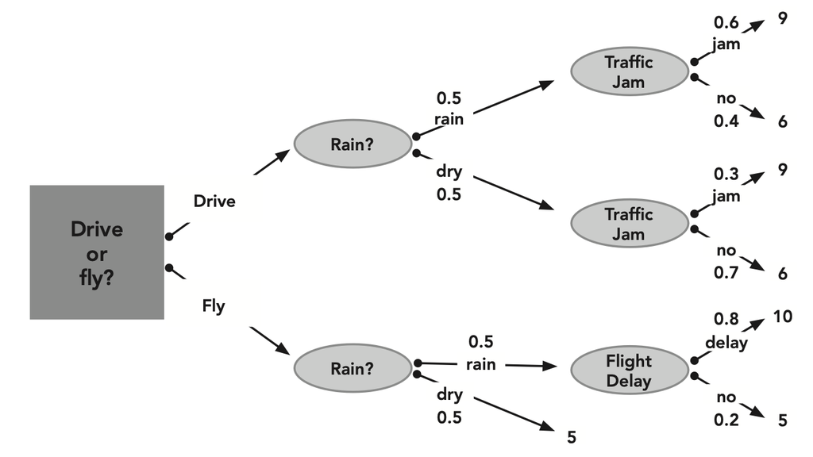

1. 7.8
2. 6.9
3. 7.4
4. 7.0

### 10.45.1 Answer

`d. 7.0`

### 10.45.2 Explanation

- **Rollback Technique**: This involves working backwards from the end of the decision tree to the beginning to determine the optimal decision path.
- **Expected Value Calculation**: The expected value of flying is calculated by considering the probabilities and the corresponding travel times.

If flying and it rains, the expected delay is:
$$0.8 \times 10 + 0.2 \times 5 = 9 \text{
hours}$$

If flying and dry weather, the flight takes 5 hours.

So the overall expected flight time is:
$$0.5 \times 9 + 0.5 \times 5 = 7 \text{
hours}$$

For driving, if it rains, the expected drive time is:
$$0.6 \times 9 + 0.4 \times 6 = 7.8 \text{
hours}$$

In summary, using the rollback technique and calculating the expected values, the optimal travel time decision is $7.0 \text{ hours}$.

## 10.46 **Question 46**

An analytics professional is responsible for maintaining a simulation model that is used to determine the staffing levels required for a specific operational business process. Assuming that the operational team always uses the number of staff determined by the model, which of the following is the MOST important maintenance activity?

1. Ensure that all the model input data items are available when needed.
2. Determine if there has been a change in model accuracy over time.
3. Ensure that all users are reviewing the model results in a timely fashion.
4. Determine that the model’s reports are understood by the users.

### 10.46.1 Answer

`b. Determine if there has been a change in model accuracy over time.`

The most important maintenance activity for the analytics professional responsible for maintaining the simulation model is to monitor the accuracy of the model over time. If there has been a change in accuracy, the analytics professional may need to revisit the assumptions of the model.

### 10.46.2 Explanation

- **Model Accuracy**: Ensuring that the model remains accurate over time is critical for its reliability and effectiveness. Changes in business conditions or input data can impact model performance.
- **Assumption Re-evaluation**: Regularly checking for changes in accuracy allows for timely updates to the model’s assumptions and parameters, maintaining its relevance and accuracy.

In summary, monitoring and maintaining model accuracy over time is crucial for ensuring that the simulation model continues to provide reliable staffing level recommendations.

## 10.47 **Question 47**

A segmentation of customers who shop at a retail store may be performed using which of the following methods?

1. Monte Carlo Markov Chain and ANOVA
2. Clustering, factor and control charts
3. Decision tree and recursive function analyses
4. Clustering and decision trees

### 10.47.1 Answer

`d. Clustering and decision trees`

Customer segmentation consists of dividing a customer base into groups of individuals that are similar in specific ways relevant to marketing, e.g., age, gender, interests, spending habits and so on. The purpose of customer segmentation is to allow a company to target specific groups of customers effectively and allocate marketing resources to best effect. Two ways to do this segmentation are clustering and decision trees.

### 10.47.2 Explanation

- **Clustering**: This method groups customers based on similarities in their attributes, such as purchasing behavior, demographics, or preferences. Common algorithms include K-means and hierarchical clustering.
- **Decision Trees**: Decision trees classify customers based on decision rules derived from their attributes. They can help identify distinct customer segments and the factors that define them.

In summary, using clustering and decision trees for customer segmentation helps identify and target specific customer groups effectively, optimizing marketing efforts.

## 10.48 **Question 48**

In the diagram below, what is true of Strategy B compared to Strategy A?

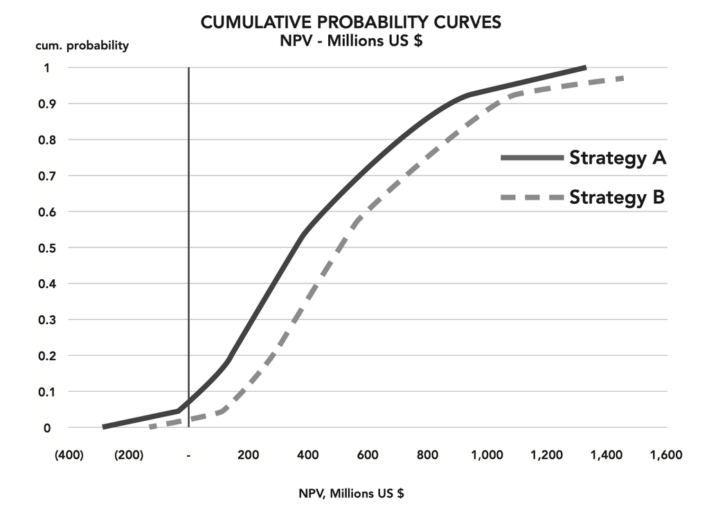

1. Strategy B exhibits stochastic (probabilistic) dominance over Strategy A.
2. Strategy B has the same downside risk as Strategy A since the curves have the same shape.
3. Strategy B must have the same uncertainties impacting it as Strategy A because the curves are so similar in shape.
4. Strategy A exhibits stochastic (probabilistic) dominance over Strategy B.

### 10.48.1 Answer

`a. Strategy B exhibits stochastic (probabilistic) dominance over Strategy A.`

Because the cumulative probability curve for Strategy B is below (or to the right) of the corresponding curve for Strategy A, it can be said that Strategy B exhibits stochastic dominance (SD) over Strategy A. B stochastically dominates A when, for any good outcome x, B gives at least as high a probability of receiving at least x as does A, and for some x, B gives a higher probability of receiving at least x. Since the curves do not cross, B stochastically dominates A.

### 10.48.2 Explanation

In summary, Strategy B exhibits stochastic dominance over Strategy A, meaning it provides better or equal outcomes across all levels of risk.

## 10.49 **Question 49**

Each month you generate a list of marketing leads for direct mail campaigns. Which of the following should you do before the list is used?

1. Exclude people who were on the list the previous month.
2. Retain x% of the leads as control for performance measurement.
3. Remove opt-outs.
4. Exclude people who were never on the list.

### 10.49.1 Answer

`c. Remove opt-outs.`

The list of marketing leads should not include people or organizations that have opted out.

### 10.49.2 Explanation

- **Compliance**: Removing opt-outs ensures compliance with regulations and respects the preferences of individuals who have chosen not to receive marketing communications.
- **Customer Relationship**: Respecting opt-outs helps maintain a positive relationship with customers and avoids potential complaints or negative sentiment.
- **Data Accuracy**: Keeping the list updated by removing opt-outs ensures that the marketing campaign is targeted at receptive audiences, improving the effectiveness of the campaign.

In summary, removing opt-outs from the marketing leads list is essential to comply with regulations, maintain customer relationships, and enhance campaign effectiveness.

## 10.50 **Question 50**

When analyzing responses of a survey of why people like a certain restaurant, factor analysis could reduce the dimension in which of the following ways?

1. Collapse several survey questions regarding food taste, health value, ingredients and consistency into one general unobserved “food quality” variable.
2. Condense similar survey respondent answers into clusters of like-minded customers for market segment analysis.
3. Reduce the variability of individual subject ratings by centering each respondent’s ratings around his or her average rating.
4. Decrease variability by analyzing inter-rater reliability on the question items before offering the survey to a wide number of respondents.

### 10.50.1 Answer

`a. Collapse several survey questions regarding food taste, health value, ingredients and consistency into one general unobserved “food quality” variable.`

Factor analysis is a statistical method used to describe variability among observed variables in terms of a potentially lower number of unobserved variables called factors. The information gained about the interdependencies between observed variables can be used later to reduce the set of variables in a dataset.

### 10.50.2 Explanation

- **Dimensionality Reduction**: Factor analysis reduces the number of variables by identifying underlying factors that explain the correlations among observed variables. For example, questions about food taste, health value, ingredients, and consistency can be grouped into a single factor representing “food quality.”
- **Simplification**: This process simplifies the dataset by collapsing multiple related variables into a smaller set of factors, making it easier to analyze and interpret the data.
- **Identifying Key Factors**: Factor analysis helps in identifying the key factors that influence respondents’ preferences, providing a more concise and meaningful representation of the data.

In summary, factor analysis reduces dimensionality by collapsing several related survey questions into one general unobserved variable, simplifying the data for analysis.

## 10.51 **Question 51**

A preferred method or best practice for organizing data in a data warehouse for reporting and analysis is:

1. transactional-based modeling.
2. multidimensional modeling.
3. relation-based modeling.
4. tuple-based modeling.

### 10.51.1 Answer

`b. multidimensional modeling.`

Multidimensional modeling is the optimum way to organize data in a data warehouse for analysis. It is associated with OLAP (On-line Analytical Processing). OLAP data is organized in cubes that can be taken directly from the data warehouse for analysis.

### 10.51.2 Explanation

- **Multidimensional Modeling**: This method organizes data into a structure that supports complex queries and analysis, typically involving multiple dimensions such as time, geography, and product categories.
- **OLAP**: Multidimensional modeling is closely associated with OLAP, which allows for efficient querying and analysis of large datasets. Data is organized in cubes, facilitating fast and flexible data exploration.
- **Efficiency and Usability**: Multidimensional models provide a user-friendly and efficient way to analyze data, supporting various analytical operations like slicing, dicing, drilling down, and rolling up.

In summary, multidimensional modeling is the best practice for organizing data in a data warehouse, supporting efficient reporting and analysis through OLAP techniques.

# 11 *Acknowledgments*

This study guide has been enhanced and expanded to aid in the preparation for the Associate Certified Analytics Professional (aCAP) exam. The content includes additional details and explanations to provide a more comprehensive understanding of the exam domains. The original framework and much of the core material have been derived from publicly available resources related to the aCAP exam provided by INFORMS.

**Sources and Contributions:**

- **INFORMS:** The foundational structure and key content areas are based on the INFORMS Job Task Analysis and other related resources provided by INFORMS for the aCAP exam.
- **ChatGPT:** Used for generating detailed explanations, expanding content, and formatting the study guide for clarity and comprehensiveness.
- **Claude:** Employed for additional content generation and enhancements.
- **Gemini:** Utilized for further refinement and ensuring completeness of the study guide.

**Legal Disclaimer:** This study guide is intended solely for educational and personal use. It is not for sale or any form of commercial distribution. The content has been enhanced from publicly available resources and supplemented with additional insights to aid in exam preparation. All trademarks, service marks, and trade names referenced in this document are the property of their respective owners.

The author does not claim any proprietary rights over the original content provided by INFORMS or any other referenced sources. This guide is provided “as is” without warranty of any kind, either express or implied. Use of this guide does not guarantee passing the aCAP exam, and it is recommended to use official resources and study materials provided by INFORMS and other reputable sources in conjunction with this guide.

By using this study guide, you acknowledge that you understand and agree to the terms stated in this acknowledgment section.